# Distribution_Basics

MS_ThinkLabz_Chennai

# Introduction

Random variable and theoretical distributions play very important role in modeling uncertainty. It offers a syntactic approach for the languge of uncertainty. Many standard texts such as [this](https://www.amazon.com/Statistical-Inference-George-Casella/dp/0534243126) on Mathematical Statistics and / or Statistical Inference deal with Distributions extensively.

# Few important keywords

- Random variable
- Range of a random variable
- Nature of a variable based on its range
  - Discrete / Continuous
  - Bounded / Unbounded (Finite / Infinite)
  - Countable / Uncountable
- Probability Mass / Density Functions (PMF/PDF)
- Summarizing a distribution
  - Expectation of functions of a random variable
  - Probability statements about a random variable
  - Order statistics of a random variable
- Need for Theoretical distributions
- Nature and Role of parameters

# Conventional notations

Following is a broad way of understanding various symbols used to represent random variables and distributions. However, this can be modified in a specific context; for more details, please [refer](https://en.wikipedia.org/wiki/List_of_mathematical_symbols_by_subject)

- Variables: Upper case Latin alphabets $X, Y, Z$ (preferably last 6 letters)
- Unknown Value of a variable: Lower case Latin alphabets $x, y, z$ (preferably last 6 letters)
- Constants: Lower case Latin alphabets $a, b, c$ (preferably first 5 letters)
- Parameters: Lower case Latin alphabets $a,b,c,k,l, m, n$ (except possibly the last 5 letters) or Lower case Greek alphabets $\alpha, \beta, \gamma$
- Also, Upper case Latin alphabets are used to list more variables $X_1, X_2, \cdots\cdots X_n$ and values of corresponding variables are denoted using lower case Latin alphabets $x_1, x_2, \cdots\cdots x_n$ are used.
- In the previous point, we could note another aspect called *index* to specify the number of variables.Lower Latin alphabets are used for index such as $i=1,2,3\cdots\cdots N$ or $j=1,2,3\cdots\cdots n$
- Collectively, in the language of Mathematical Statistics,
  $$X \sim f(X|\theta)$$
  implies that X is random variable with PDF $f$ with parameter $\theta$
  - $\theta$ can be any dimension
  - Range of X is denoted as $\mathscr{A}_X$
  - $|$ **should** be read as given
  - $f(X|\theta)$ should be read as, “probability mass (density) function of x **given** $\theta$ is equal to ……..”
  - Whenever $\theta$ is known, $f(x|\theta)$ computes value of the function at $x$ of $X$

# Functional form of Distributions

There can be infinitely many ways to define mathematical form for a distribution satisfying two conditions; non-negativity and total probability is 1. However, such possibilities may be understood by realizing few mathematical functions and five operations $+,~-,~\times,~\div,$and $\circ$; last one $\circ$ indicates composition of functions

1. Constant Function $f(x)=k$
2. Power Function $f(x) = x^k$, except possibly at $x=0$
3. Exponential Function $f(x) = k^x$ with $k>0$; in particular $k=e$ draws much scientific attention
4. Logarithmic functions $f(x) = \log_{a}x$ where $a>0$ is the base
   1. Common logarithm: $a=10$
   2. Natural logarithm: $a=e$
5. Circular trigonometric functions

Each of the above five functions exhibit intereting characteristics for suitable values of respective parameters. In statistical paradigm three types of parameters are more prominent; *location, shape, and scale* parameters.

# Visual Representations

In this section, we provide some graphical form of above functional representations. Also, the role of parameters could be visually understood

## Location Parameter

For the first curve $x^2$, zero is the origin; in other two curves, origin is shifted by three units on either side of zero.

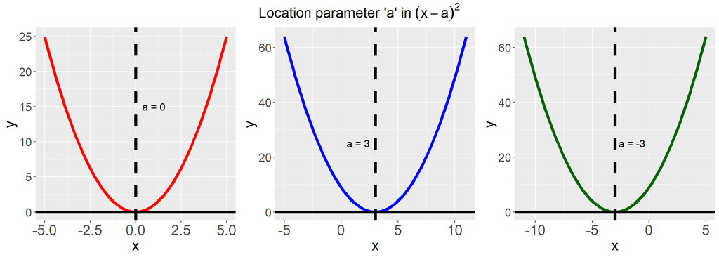

```r
library(ggplot2)
library(gridExtra)
library(grid)
PFun1 <- function(x) {
       x^2
}
PFun2 <- function(x) {
       (x-3)^2
}

PFun3 <- function(x) {
       (x+3)^2
}

p1=ggplot(data.frame(x = c(-5, 5)), aes(x = x)) +
       stat_function(fun = PFun1,col="red",size=2)+
       geom_vline(xintercept=0, lty=2,size=2)+
       geom_hline(yintercept=0, size=2)+
       geom_text(x = 1, y = 15, label = 'a = 0',size=5)+
   theme(text = element_text(size=20),
         axis.text.x = element_text(size = 20))

p2=ggplot(data.frame(x = c(-5, 11)), aes(x = x))+
stat_function(fun = PFun2,col="blue",size=2)+
       geom_vline(xintercept=3, lty=2,size=2)+
       geom_hline(yintercept=0, size=2)+
       geom_text(x = 1.5, y = 25, label = 'a = 3',size=5)+
   theme(text = element_text(size=20),
         axis.text.x = element_text(size = 20))


p3=ggplot(data.frame(x = c(-11, 5)), aes(x = x))+
       stat_function(fun = PFun3,col="darkgreen",size=2)+
       geom_vline(xintercept=-3, lty=2,size=2)+
       geom_hline(yintercept=0, size=2)+
       geom_text(x = -1.5, y = 25, label = 'a = -3',size=5)+
   theme(text = element_text(size=20),
         axis.text.x = element_text(size = 20))


grid.arrange(p1, p2,p3, ncol = 3,
        top = textGrob("Location parameter 'a' in" ~(x-a)^2,
            gp = gpar(col = "black", fontsize = 20)))
```

## Scale Parameter

For different values of scale parameter $b$ in $e^{-\frac{x}{b}}$ from 0 to 2

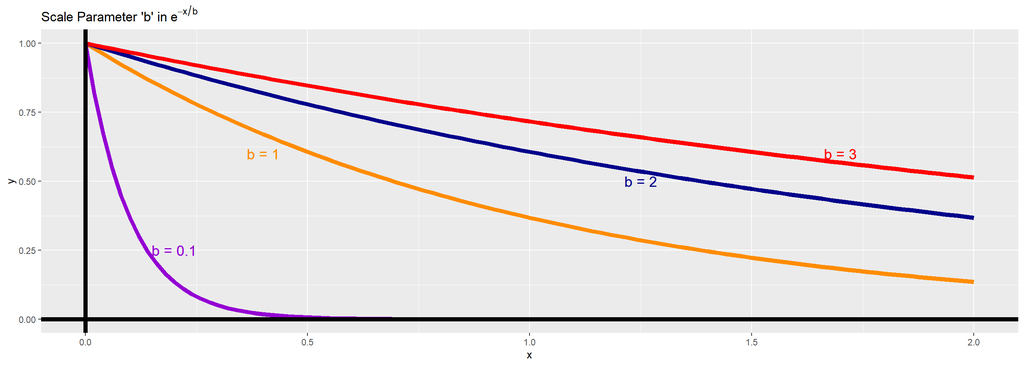

```r
EFun1 <- function(x) {
       exp(-x)
}
EFun2 <- function(x) {
       exp(-x/2)
}

EFun3 <- function(x) {
       exp(-x/3)
}

EFun4 <- function(x) {
       exp(-10*x)
}

ggplot(data.frame(x = c(0, 2)), aes(x = x))+
  stat_function(fun = EFun1,col="darkorange",size=2)+
  stat_function(fun = EFun2,col="darkblue",size=2)+
  stat_function(fun = EFun3,col="red",size=2)+
  stat_function(fun = EFun4,col="darkviolet",size=2)+
  geom_vline(xintercept=0, size=2)+
  geom_hline(yintercept=0, size=2)+
  geom_text(x = 0.40, y = 0.60, label = 'b = 1',col="darkorange",size=5)+
  geom_text(x = 1.25, y = 0.50, label = 'b = 2',col="darkblue",size=5)+
  geom_text(x = 1.70, y = 0.60, label = 'b = 3',col="red",size=5)+
  geom_text(x = 0.20, y = 0.25, label = 'b = 0.1',col="darkviolet",size=5)+
  labs(title = bquote("Scale Parameter 'b' in"~e^{-x/b}),size=20)
```

## Scale and Location Parameters

Some examples for combination of scale and location parameters, $\frac{1}{b}f(\frac{(x-a)}{b})$. In the following, first curve has scale = 1 to compare when $b > 1 ~\mathrm{or}~ < 1$

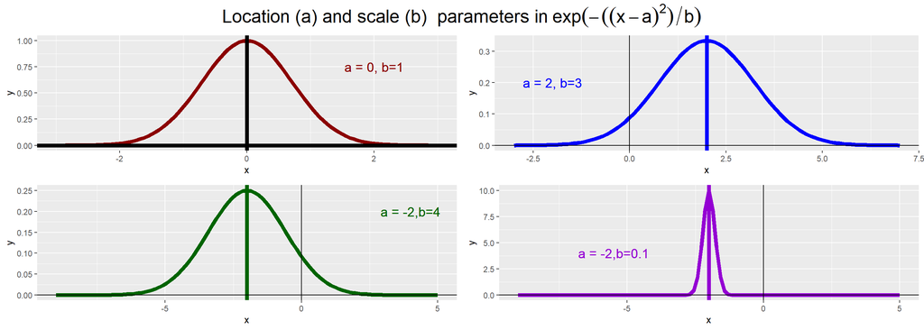

```r
EPFun1 <- function(x) {
       exp(-x^2)
}
EPFun2 <- function(x) {
      (1/3)*exp(-(1/3)*(x-2)^2)
}

EPFun3 <- function(x) {
       (1/4)*exp(-(1/4)*(x+2)^2)
}

EPFun4 <- function(x) {
      (1/0.1)*exp(-(1/0.1)*(x+2)^2)
}

p1=ggplot(data.frame(x = c(-3, 3)), aes(x = x)) +
       stat_function(fun = EPFun1,col="darkred",size=2)+
       geom_vline(xintercept=0, size=2)+
       geom_hline(yintercept=0, size=2)+
       geom_text(x = 2, y = 0.75, label = 'a = 0, b=1',col="darkred",size=5)

p2=ggplot(data.frame(x = c(-3, 7)), aes(x = x))+
       stat_function(fun = EPFun2,col="blue",size=2)+
       geom_vline(xintercept=0)+
       geom_vline(xintercept=2, col="blue",size=2)+
       geom_hline(yintercept=0)+
      geom_text(x = -2, y = 0.2, label = 'a = 2, b=3',col="blue",size=5)

p3=ggplot(data.frame(x = c(-9, 5)), aes(x = x))+
       stat_function(fun = EPFun3,col="darkgreen",size=2)+
       geom_vline(xintercept=0)+
       geom_vline(xintercept=-2, col="darkgreen",size=2)+
       geom_hline(yintercept=0)+
       geom_text(x = 4, y = 0.2, label = 'a = -2,b=4',col="darkgreen",size=5)

p4=ggplot(data.frame(x = c(-9, 5)), aes(x = x))+
       stat_function(fun = EPFun4,col="darkviolet",size=2)+
       geom_vline(xintercept=0)+
       geom_vline(xintercept=-2, col="darkviolet",size=2)+
       geom_hline(yintercept=0)+
       geom_text(x = -5.5, y = 4, label = 'a = -2,b=0.1',col="darkviolet",size=5)

grid.arrange(p1, p2,p3,p4,nrow=2, ncol = 2,
top = textGrob("Location (a) and scale (b)  parameters in" ~exp(-((x-a)^2)/b),
            gp = gpar(col = "black", fontsize = 20)))
```

## Shape Parameter

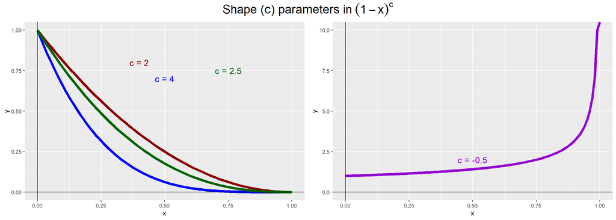

```r
SFun1 <- function(x) {
       (1-x)^2
}
SFun2 <- function(x) {
       (1-x)^4
}

SFun3 <- function(x) {
       (1-x)^2.5
}

SFun4 <- function(x) {
       (1-x)^-0.5
}

p1=ggplot(data.frame(x = c(0, 1)), aes(x = x)) +
       stat_function(fun = SFun1,col="darkred",size=2)+
       stat_function(fun = SFun2,col="blue",size=2)+
       stat_function(fun = SFun3,col="darkgreen",size=2)+
       geom_vline(xintercept=0)+
       geom_hline(yintercept=0)+
       geom_text(x = 0.4, y = 0.8, label = 'c = 2', col="darkred", size=5)+
       geom_text(x = 0.5, y = 0.7, label = 'c = 4', col="blue", size=5)+
       geom_text(x = 0.75, y = 0.75, label = 'c = 2.5', col="darkgreen",size=5)

p2=ggplot(data.frame(x = c(0, 1)), aes(x = x))+
       stat_function(fun = SFun4,col="darkviolet",size=2)+
       geom_vline(xintercept=0)+
       geom_hline(yintercept=0)+
       geom_text(x = 0.5, y = 2, label = 'c = -0.5',col="darkviolet",size=5)

grid.arrange(p1, p2, ncol = 2,nrow=1,
             top = textGrob("Shape (c) parameters in" ~(1-x)^c, gp = gpar(col = "black", fontsize = 20)))
```

**Few more examples for combination of shape and location parameters**

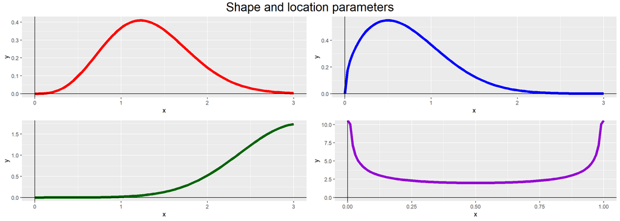

```r
Fun1 <- function(x) {
       x^3*exp(-x^2)
}
Fun2 <- function(x) {
       x^0.5*exp(-x^2)
}

Fun3 <- function(x) {
       x^0.5*exp(-(x-3)^2)
}

Fun4 <- function(x) {
       x^-0.5*(1-x)^-0.5
}

p1=ggplot(data.frame(x = c(0, 3)), aes(x = x)) +
       stat_function(fun = Fun1,col="red",size=2)+
       geom_vline(xintercept=0)+
       geom_hline(yintercept=0)

p2=ggplot(data.frame(x = c(0, 3)), aes(x = x))+
       stat_function(fun = Fun2,col="blue",size=2)+
       geom_vline(xintercept=0)+
       geom_hline(yintercept=0)

p3=ggplot(data.frame(x = c(0, 3)), aes(x = x))+
       stat_function(fun = Fun3,col="darkgreen",size=2)+
       geom_vline(xintercept=0)+
       geom_hline(yintercept=0)

p4=ggplot(data.frame(x = c(0, 1)), aes(x = x))+
       stat_function(fun =Fun4,col="darkviolet",size=2)+
       geom_vline(xintercept=0)+
       geom_hline(yintercept=0)

grid.arrange(p1, p2,p3,p4,nrow=2, ncol = 2,
 top = grid::textGrob("Shape and location parameters",
            gp = gpar(col = "black", fontsize = 20)))
```

# Reading a Theoretical distribution

A theoretical distribution has practical reasoning so as to define in a functional form as described earlier. Following three are just to exemplify the basic requirements one has to know about a distribution. Genesis of many standard theoretical distributions (and other features) may be referred [here](https://www.amazon.ae/Continuous-Univariate-Distributions-Norman-Johnson/dp/0471584940); other similar texts by these authors are also worth reading.

**Normal distribution**

- PDF: $\frac{1}{\sqrt{2\pi\sigma^2}}e^{-\frac{(x-\mu)^2}{2\sigma^2}}$
- Parameters: Location: $\mu$, Scale: $\sigma^2$
- Range of X, $\mathscr{A}$: $-\infty \lt x \lt\infty$
- Parameter Space: $-\infty\lt\mu\lt\infty$, $\sigma^2\gt0$

**Beta distribution**

- PDF: $\frac{1}{\beta(\alpha,\beta)}x^{(\alpha-1)}(1-x)^{(\beta-1)}$
- Parameters: Shape: $\alpha,\beta$
- Range of X, $\mathscr{A}$: $0\lt x\lt1$
- Parameter Space: $\alpha\gt0$,$\beta\gt0$

**Binomial distribution**

- PDF: ${n \choose x} \theta^x (1-\theta)^{n-x}$
- Parameters: Shape: $n,\theta$
- Range of X, $\mathscr{A}$: $x = 0,1,2,...,n$
- Parameter Space: $0\lt \theta \lt1$, $n\gt0$ integer

# Final Remarks

- Five basic forms of a function and associated operations would help in understanding varioud possible forms of a functions
- These aspects are controlled by parameters in a function. In Statistical theory, they play vital roles in modeling many real time scenarios.
- Hence, in a pdf $f(x|\theta)$ it is equally important of knowing the range of the variable $X$ and the parameter $\theta$ space
- Geometrically, additive and multiplicative changes and shape of a functions are effected using **location, scale and shape parameters**.
- There are mathematical forms to represent real-time scenarios. A theoretical distribution may vary in its nature, range and parameter space depending on the purpose and need for its reasoning.
- Web resources like [Wiki](https://en.wikipedia.org/wiki/Pareto_distribution) are also notable references for theoretical disributions.One common aspect in any such resource is the inclusion of aforementioned keywords.
- As an initial understanding, this notes attempts to explain the mathematical form of random variable and associated parameters.